# Virtual competition 1-Solution

Consider the following Python dictionary `data` and Python list `labels`:

```
data = {'animal': ['cat', 'cat', 'snake', 'dog', 'dog', 'cat', 'snake', 'cat', 'dog', 'dog'],
        'age': [2.5, 3, 0.5, np.nan, 5, 2, 4.5, np.nan, 7, 3],
        'visits': [1, 3, 2, 3, 2, 3, 1, 1, 2, 1],
        'priority': ['yes', 'yes', 'no', 'yes', 'no', 'no', 'no', 'yes', 'no', 'no']}

labels = ['a', 'b', 'c', 'd', 'e', 'f', 'g', 'h', 'i', 'j']
```

**1.** Create a DataFrame `df` from this dictionary `data` which has the index `labels`.

```python
import pandas as pd
import numpy as np
import seaborn as sns
import matplotlib.pyplot as plt
```

```python
data = {'animal': ['cat', 'cat', 'snake', 'dog', 'dog', 'cat', 'snake', 'cat', 'dog', 'dog'],
        'age': [2.5, 3, 0.5, np.nan, 5, 2, 4.5, np.nan, 7, 3],
        'visits': [1, 3, 2, 3, 2, 3, 1, 1, 2, 1],
        'priority': ['yes', 'yes', 'no', 'yes', 'no', 'no', 'no', 'yes', 'no', 'no']}

labels = ['a', 'b', 'c', 'd', 'e', 'f', 'g', 'h', 'i', 'j']

df = pd.DataFrame(data, index=labels)
print(df)
```

```
  animal  age  visits priority
a    cat  2.5       1      yes
b    cat  3.0       3      yes
c  snake  0.5       2       no
d    dog  NaN       3      yes
e    dog  5.0       2       no
f    cat  2.0       3       no
g  snake  4.5       1       no
h    cat  NaN       1      yes
i    dog  7.0       2       no
j    dog  3.0       1       no
```

**2.** Display a summary of the basic information about this DataFrame and its data (*hint: there is a single method that can be called on the DataFrame*).

```python
df.describe().T
```

|  | count | mean | std | min | 25% | 50% | 75% | max |
| --- | --- | --- | --- | --- | --- | --- | --- | --- |
| age | 8.0 | 3.4375 | 2.007797 | 0.5 | 2.375 | 3.0 | 4.625 | 7.0 |
| visits | 10.0 | 1.9000 | 0.875595 | 1.0 | 1.000 | 2.0 | 2.750 | 3.0 |

```python
df.describe(include='object').T
```

|  | count | unique | top | freq |
| --- | --- | --- | --- | --- |
| animal | 10 | 3 | cat | 4 |
| priority | 10 | 2 | no | 6 |

**3.** Return the first 3 rows of the DataFrame `df`.

```python
df.head(3)
```

|  | animal | age | visits | priority |
| --- | --- | --- | --- | --- |
| a | cat | 2.5 | 1 | yes |
| b | cat | 3.0 | 3 | yes |
| c | snake | 0.5 | 2 | no |

**4.** Display the 'animal' and 'age' columns from the DataFrame `df`

```python
df[['animal','age']]
```

|  | animal | age |
| --- | --- | --- |
| a | cat | 2.5 |
| b | cat | 3.0 |
| c | snake | 0.5 |
| d | dog | NaN |
| e | dog | 5.0 |
| f | cat | 2.0 |
| g | snake | 4.5 |
| h | cat | NaN |
| i | dog | 7.0 |
| j | dog | 3.0 |

**5.** Display the data in rows `[3, 4, 8]` *and* in columns `['animal', 'age']'

```python
df.iloc[[2, 3, 7], [0, 1]]
```

|  | animal | age |
| --- | --- | --- |
| c | snake | 0.5 |
| d | dog | NaN |
| h | cat | NaN |

**6.** Select only the rows where the number of visits is greater than 3.

```python
df[df['visits']>3]
```

|  | animal | age | visits | priority |
| --- | --- | --- | --- | --- |

No entries with visits greater than 3

**7.** Select the rows where the age is missing, i.e. it is `NaN`.

```python
df[df['age'].isna()]
```

|  | animal | age | visits | priority |
| --- | --- | --- | --- | --- |
| d | dog | NaN | 3 | yes |
| h | cat | NaN | 1 | yes |

**8.** Select the rows where the animal is a cat *and* the age is less than 3.

```python
df[(df['animal'] == 'cat') & (df['age'] < 3)]
```

|  | animal | age | visits | priority |
| --- | --- | --- | --- | --- |
| a | cat | 2.5 | 1 | yes |
| f | cat | 2.0 | 3 | no |

**9.** Select the rows where the age is between 2 and 4 (inclusive)

```python
df[(df['age'] >= 2) & (df['age'] <= 4)]
```

|  | animal | age | visits | priority |
| --- | --- | --- | --- | --- |
| a | cat | 2.5 | 1 | yes |
| b | cat | 3.0 | 3 | yes |
| f | cat | 2.0 | 3 | no |
| j | dog | 3.0 | 1 | no |

**10.** Change the age in row 'f' to 1.5.

```python
df.loc['f', 'age'] = 1.5
df
```

|  | animal | age | visits | priority |
| --- | --- | --- | --- | --- |
| a | cat | 2.5 | 1 | yes |
| b | cat | 3.0 | 3 | yes |
| c | snake | 0.5 | 2 | no |
| d | dog | NaN | 3 | yes |
| e | dog | 5.0 | 2 | no |
| f | cat | 1.5 | 3 | no |
| g | snake | 4.5 | 1 | no |
| h | cat | NaN | 1 | yes |
| i | dog | 7.0 | 2 | no |
| j | dog | 3.0 | 1 | no |

**11.** Calculate the sum of all visits in `df` (i.e. the total number of visits).

```python
df['visits'].sum()
```

```
19
```

**12.** Calculate the mean age for each different animal in `df`.

```python
df.groupby('animal')['age'].mean()
```

```
animal
cat      2.333333
dog      5.000000
snake    2.500000
Name: age, dtype: float64
```

**13.** Append a new row 'k' to `df` with your choice of values for each column. Then delete that row to return the original DataFrame.

```python
df.loc['k'] = ['cow', 3, 2, 'yes']
df
```

|  | animal | age | visits | priority |
| --- | --- | --- | --- | --- |
| a | cat | 2.5 | 1 | yes |
| b | cat | 3.0 | 3 | yes |
| c | snake | 0.5 | 2 | no |
| d | dog | NaN | 3 | yes |
| e | dog | 5.0 | 2 | no |
| f | cat | 1.5 | 3 | no |
| g | snake | 4.5 | 1 | no |
| h | cat | NaN | 1 | yes |
| i | dog | 7.0 | 2 | no |
| j | dog | 3.0 | 1 | no |
| k | cow | 3.0 | 2 | yes |

```python
df=df.drop('k')
df
```

|  | animal | age | visits | priority |
| --- | --- | --- | --- | --- |
| a | cat | 2.5 | 1 | yes |
| b | cat | 3.0 | 3 | yes |
| c | snake | 0.5 | 2 | no |
| d | dog | NaN | 3 | yes |
| e | dog | 5.0 | 2 | no |
| f | cat | 1.5 | 3 | no |
| g | snake | 4.5 | 1 | no |
| h | cat | NaN | 1 | yes |
| i | dog | 7.0 | 2 | no |
| j | dog | 3.0 | 1 | no |

**14.** Count the number of each type of animal in `df`.

```python
animal_counts = df['animal'].value_counts()
print(animal_counts)
```

```
cat      4
dog      4
snake    2
Name: animal, dtype: int64
```

**15.** Sort `df` first by the values in the 'age' in *decending* order, then by the value in the 'visits' column in *ascending* order (so row `i` should be first, and row `d` should be last).

```python
df = df.sort_values(by=['age', 'visits'], ascending=[False, True])
df
```

|  | animal | age | visits | priority |
| --- | --- | --- | --- | --- |
| i | dog | 7.0 | 2 | no |
| e | dog | 5.0 | 2 | no |
| g | snake | 4.5 | 1 | no |
| j | dog | 3.0 | 1 | no |
| b | cat | 3.0 | 3 | yes |
| a | cat | 2.5 | 1 | yes |
| f | cat | 1.5 | 3 | no |
| c | snake | 0.5 | 2 | no |
| h | cat | NaN | 1 | yes |
| d | dog | NaN | 3 | yes |

**16.** The 'priority' column contains the values 'yes' and 'no'. Replace this column with a column of boolean values: 'yes' should be `True` and 'no' should be `False`.

```python
df['priority'] = df['priority'].replace({'yes': True, 'no': False})
df
```

|  | animal | age | visits | priority |
| --- | --- | --- | --- | --- |
| i | dog | 7.0 | 2 | False |
| e | dog | 5.0 | 2 | False |
| g | snake | 4.5 | 1 | False |
| j | dog | 3.0 | 1 | False |
| b | cat | 3.0 | 3 | True |
| a | cat | 2.5 | 1 | True |
| f | cat | 1.5 | 3 | False |
| c | snake | 0.5 | 2 | False |
| h | cat | NaN | 1 | True |
| d | dog | NaN | 3 | True |

**17.** In the 'animal' column, change the 'snake' entries to 'python'.

```python
df['animal'] = df['animal'].replace('snake', 'python')
df
```

|  | animal | age | visits | priority |
| --- | --- | --- | --- | --- |
| i | dog | 7.0 | 2 | False |
| e | dog | 5.0 | 2 | False |
| g | python | 4.5 | 1 | False |
| j | dog | 3.0 | 1 | False |
| b | cat | 3.0 | 3 | True |
| a | cat | 2.5 | 1 | True |
| f | cat | 1.5 | 3 | False |
| c | python | 0.5 | 2 | False |
| h | cat | NaN | 1 | True |
| d | dog | NaN | 3 | True |

**18.** Load the ny-flights dataset to Python

```python
data=pd.read_csv('ny-flights.csv')
data.head()
```

|  | fl_date | unique_carrier | airline_id | tail_num | fl_num | origin | dest | dep_time | dep_delay | arr_time | arr_delay | cancelled | arr | dep |
| --- | --- | --- | --- | --- | --- | --- | --- | --- | --- | --- | --- | --- | --- | --- |
| 0 | 2014-01-01 00:00:00 | AA | 19805 | N338AA | 1 | JFK | LAX | 914.0 | 14.0 | 1238.0 | 13.0 | 0.0 | 2014-01-01 12:38:00 | 2014-01-01 09:14:00 |
| 1 | 2014-01-01 00:00:00 | AA | 19805 | N335AA | 3 | JFK | LAX | 1157.0 | -3.0 | 1523.0 | 13.0 | 0.0 | 2014-01-01 15:23:00 | 2014-01-01 11:57:00 |
| 2 | 2014-01-01 00:00:00 | AA | 19805 | N327AA | 21 | JFK | LAX | 1902.0 | 2.0 | 2224.0 | 9.0 | 0.0 | 2014-01-01 22:24:00 | 2014-01-01 19:02:00 |
| 3 | 2014-01-01 00:00:00 | AA | 19805 | N3EHAA | 29 | LGA | PBI | 722.0 | -8.0 | 1014.0 | -26.0 | 0.0 | 2014-01-01 10:14:00 | 2014-01-01 07:22:00 |
| 4 | 2014-01-01 00:00:00 | AA | 19805 | N319AA | 117 | JFK | LAX | 1347.0 | 2.0 | 1706.0 | 1.0 | 0.0 | 2014-01-01 17:06:00 | 2014-01-01 13:47:00 |

```python
data.info()
```

```
<class 'pandas.core.frame.DataFrame'>
RangeIndex: 20817 entries, 0 to 20816
Data columns (total 14 columns):
 #   Column          Non-Null Count  Dtype
---  ------          --------------  -----
 0   fl_date         20817 non-null  object
 1   unique_carrier  20817 non-null  object
 2   airline_id      20817 non-null  int64
 3   tail_num        20512 non-null  object
 4   fl_num          20817 non-null  int64
 5   origin          20817 non-null  object
 6   dest            20817 non-null  object
 7   dep_time        18462 non-null  float64
 8   dep_delay       18462 non-null  float64
 9   arr_time        18412 non-null  float64
 10  arr_delay       18383 non-null  float64
 11  cancelled       20817 non-null  float64
 12  arr             18412 non-null  object
 13  dep             18462 non-null  object
dtypes: float64(5), int64(2), object(7)
memory usage: 2.2+ MB
```

**19.** Which airline ID is present maximum times in the dataset

```python
data['airline_id'].value_counts()
```

```
20409    4902
19790    3803
20398    2434
19805    2427
20366    2080
19393    1917
20355    1568
19977    1106
21171     301
20437     206
20436      33
19690      29
20304      11
Name: airline_id, dtype: int64
```

The airline_id 20409 is present maximum with a count of 4902.

**20.** Draw a plot between dep_delay and arr_delay

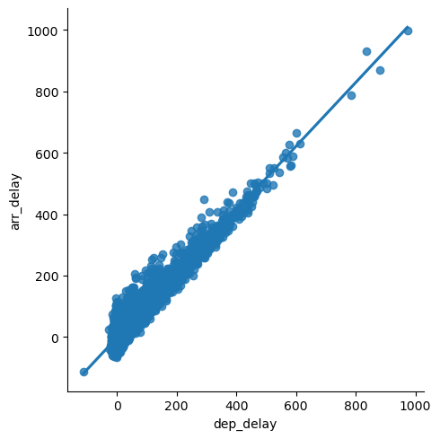

```python
sns.lmplot(data=data,x='dep_delay' ,y='arr_delay');
```

The lmplot shows that the arr_delay and dep_delay are positively correlated. As the dep_delay increases the arr_delay increases as well.